# An In-Depth Look at Study Habits: A Visual Data Story

Shray Shekaran

## Introduction

In this story, we explore the study habits of students. We analyze self reported study session data and the aim of the uncover trends in study time, subjects studied, and the frequency of multi-subject study sessions. The data collected over multiple weeks has been displayed to show how students organize their study routines and habits.

## Total Study Time Per Day

We begin by looking at the total study time per day. The line plot below visualizes the amount of time spent studying each day.

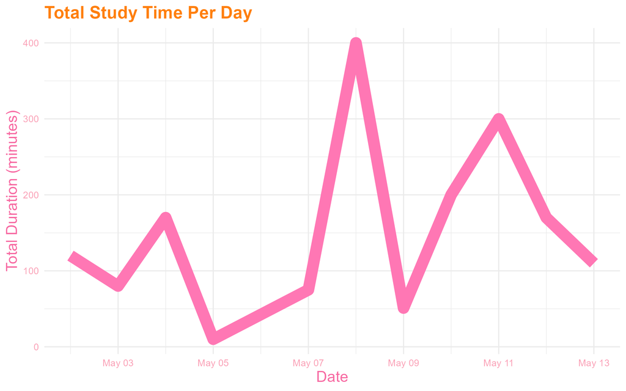

Total Study Time Per Day

This plot shows fluctuations in study time, indicating peaks and dips in student engagement over time. By analyzing this, we can identify patterns in study behavior.

## Most Frequently Studied Subjects

Next, we analyze the most frequently studied subjects. The bar chart below displays the count of sessions for each subject.

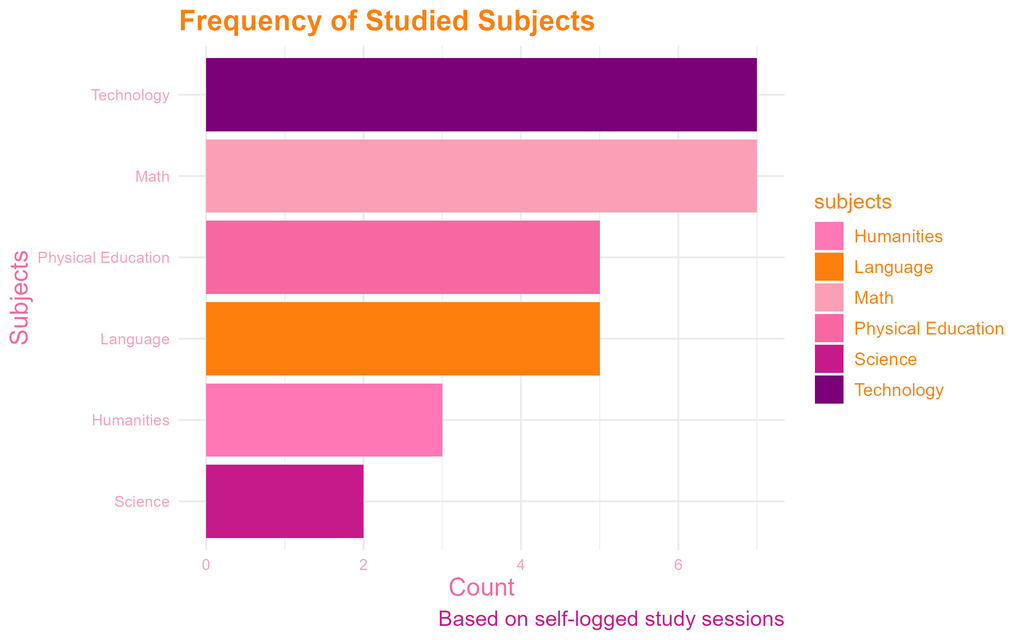

Most Frequently Studied Subjects

This chart highlights the subjects that students focus on the most, helping us understand academic priorities.

## Multi-subject Study Sessions

Finally, we examine whether students typically study multiple subjects in a single session. The pie chart below illustrates the proportion of sessions dedicated to one subject versus multiple subjects.

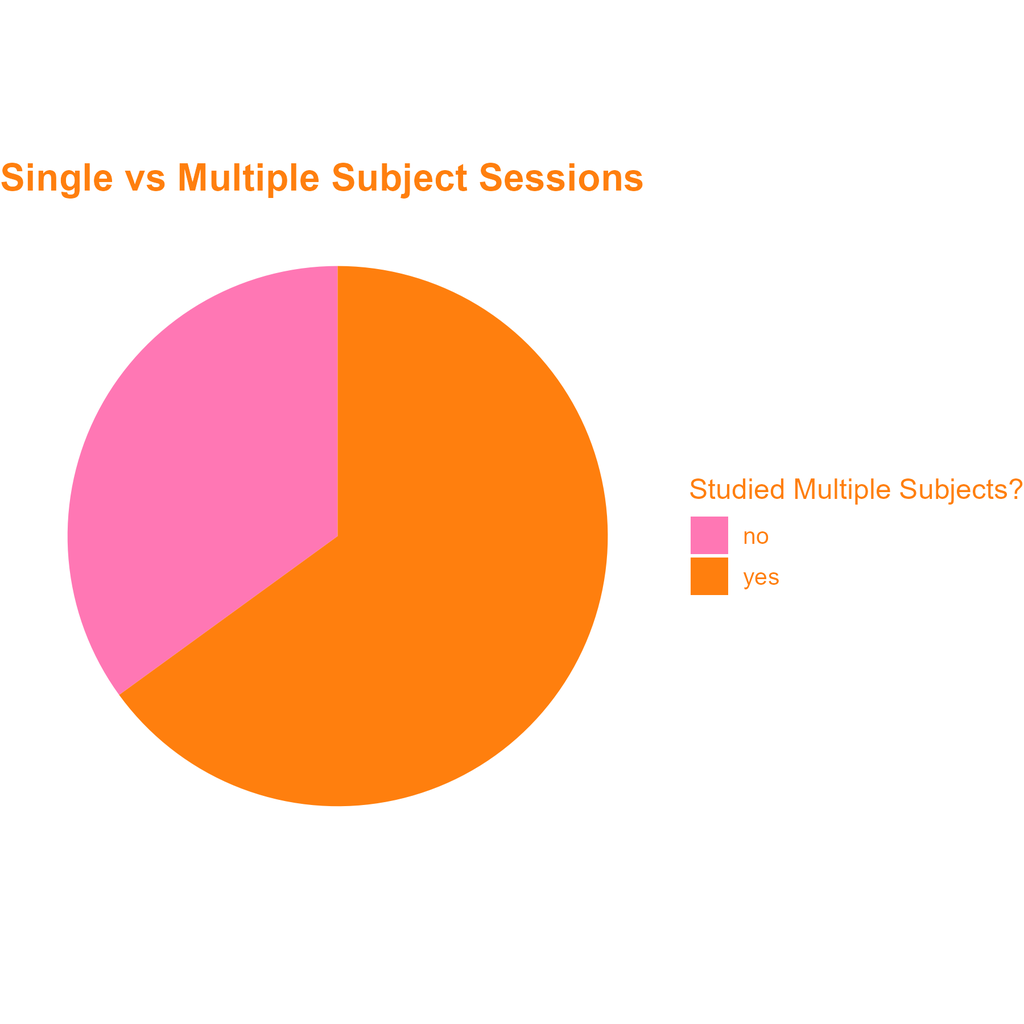

Single vs Multiple Subject Sessions